# Regional Housing Framework

Upzoning analysis for Arlington County

Library: RegHsg

Project: Regional Housing Framework

Author: Sarah Strochak

Version: R 3.5.1, RStudio 1.1.423

Last updated March 02, 2019

Environment: Local Windows session (desktop)

## Description

The goal of this analysis is to estimate the number of units to be gained from upzoning the existing housing stock within 1 mile of COG activity centers and 1/2 mile of rail, including MARC/VRE.

The metric that we use for density will be defined as units per acre.

## Set-up

Load libraries and functions

```r
library(tidyverse)
library(sf)
library(urbnthemes)
library(units)

source("../Macros/read-arlington.R")
source("../Macros/get_node_geography.R")
```

Create directory for data exports

```r
if (!dir.exists("../Data")) {
  dir.create("../Data")
}
```

Set FIPS code, filepath name, and directory for maps

```r
currentfips <- "51013"
filepath <- "arlington"
rhfdir <- "L:/Libraries/RegHsg/Maps"
```

Load in cleaned Arlington data. Fill in lot size where possible, as done in vacant lots analysis.

```r
if (!exists("jur")) {
  jur <- read_arlington(filepath)
} else {
  warning(filepath, " data already read in")
}


jur <- jur %>%
  mutate(arc_lotsize_sf = lotsize_sf, # archive the original lot size variable
         lotsize_sf = ifelse(is.na(lotsize_sf),
                             parcel_area,
                             lotsize_sf),
         lotsize_sf = ifelse(is.na(lotsize_sf),
                             lotsize_prop,
                             lotsize_sf),
         lotsize_acres = lotsize_sf / 43560)
```

Use the functions established in `clean-node-geographies.Rmd` to read in shapefiles for nodes. Start with activity centers.

```r
act1mile <- get_node_geography(node_type = "activity",
                               style = "buffer",
                               activity_buffer = 1)
```

Read in Arlington zoning layer

```r
zon <- st_read(dsn = paste0(rhfdir, "/",
                            filepath, "-zoning-map"),
               layer = "Zoning_Polygons") %>%
  st_transform(crs = 4326)
```

Convert Black Knight data to spatial.

```r
jursf <- jur %>%
  filter(!(is.na(lat) | is.na(long))) %>%
  st_as_sf(coords = c("long", "lat")) %>%
  st_set_crs(st_crs(zon))
```

## Example

Pick one activity center in Arlington to test and visualize the calculation. Use Clarendon activity center as an example.

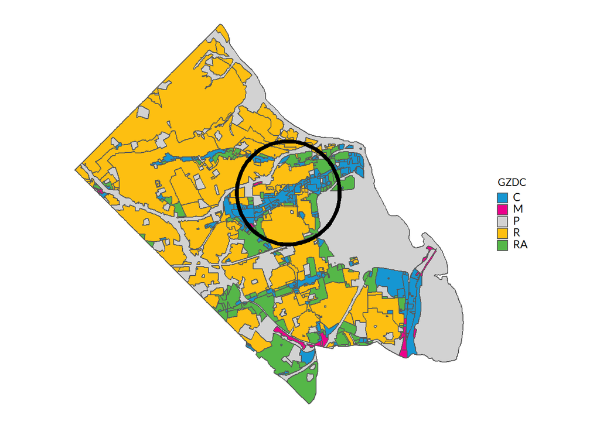

```r
clarendon <- filter(act1mile, name == "Clarendon")

ggplot() +
  geom_sf(zon, mapping = aes(fill = GZDC)) +
  scale_fill_manual(values = c("#1696d2", "#ec008b", "#d2d2d2",
                               "#fdbf11", "#55b748", "#0a4c6a")) +
  geom_sf(clarendon, mapping = aes(),
          fill = NA, size = 1.6, color = "black") +
  theme_urbn_map() +
  coord_sf(datum = NA)
```

We can clip the zoning layer and the Black Knight data to the circumference of the buffer.

```r
zon_clar <- st_intersection(zon, clarendon)
bk_clar <- st_intersection(jursf, clarendon)
```

##### Zoning layer

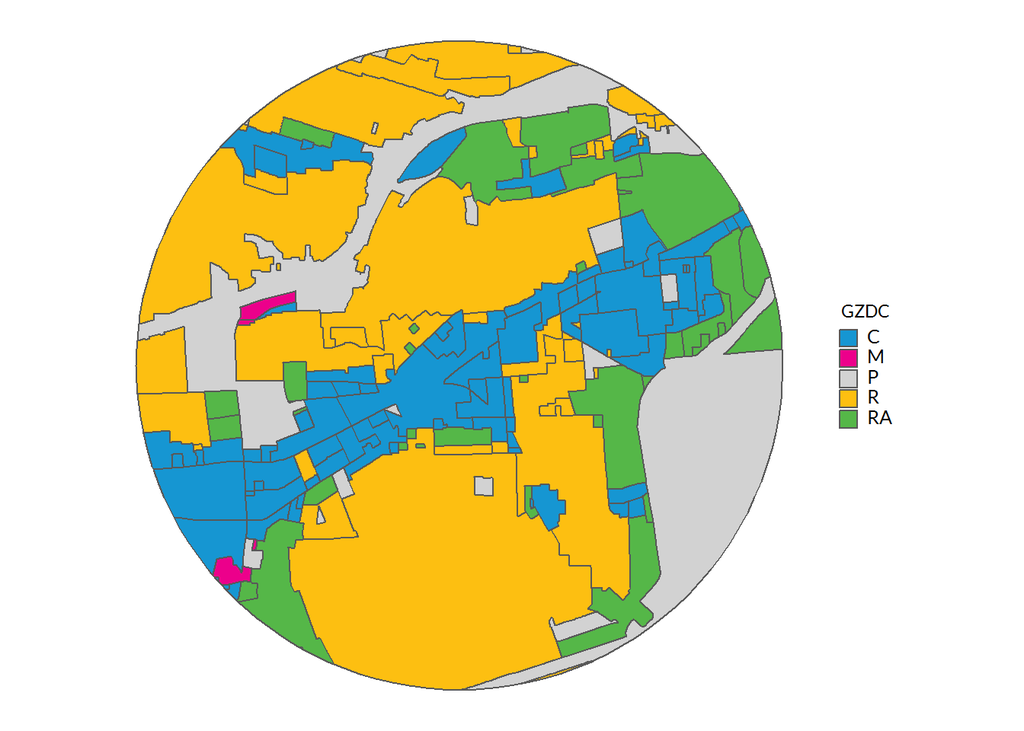

##### Black knight data

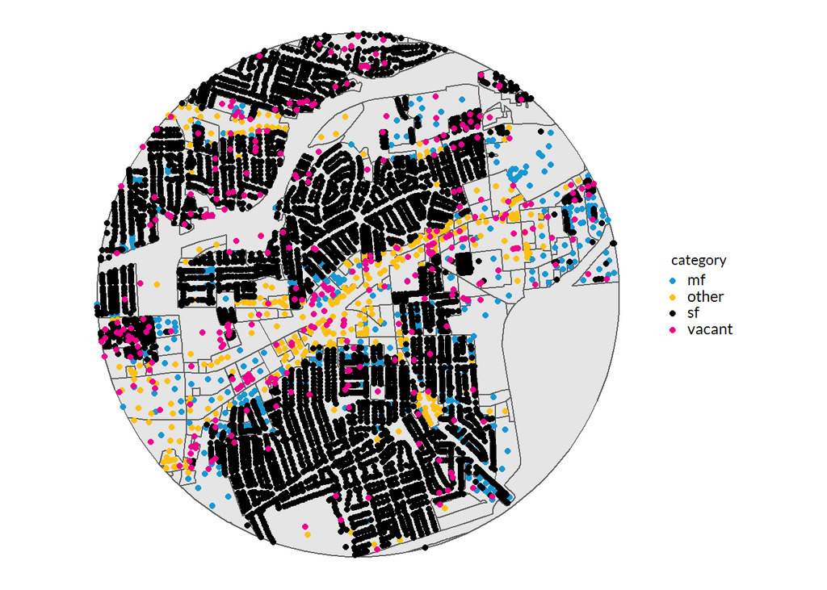

### Test zoning and land use within activity zone

Test how much of the area in the buffered zone is in each zoning code.

```r
zon_clar <- zon_clar %>%
  mutate(area = st_area(zon_clar) %>% set_units("acre"))

totalarea <- sum(zon_clar$area)
units(totalarea) <- NULL
units(zon_clar$area) <- NULL

zon_clar %>% as.data.frame() %>%
  group_by(ZN_DESIG) %>%
  summarize(area= sum(area)) %>%
  mutate(p_area = (area/totalarea) %>%
                   set_units(NULL)) %>%
  arrange(desc(p_area)) %>%
  mutate(area_sum = cumsum(p_area)) %>%
  knitr::kable()
```

| ZN_DESIG | area | p_area | area_sum |
| --- | --- | --- | --- |
| R-6 | 669.7761279 | 0.3332395 | 0.3332395 |
| S-3A | 371.2050271 | 0.1846888 | 0.5179283 |
| R-5 | 178.3130953 | 0.0887177 | 0.6066460 |
| RA8-18 | 150.8875077 | 0.0750724 | 0.6817184 |
| RA6-15 | 84.6645982 | 0.0421239 | 0.7238423 |
| C-2 | 76.3431876 | 0.0379837 | 0.7618260 |
| C-3 | 54.2312227 | 0.0269821 | 0.7888081 |
| RA7-16 | 50.9062228 | 0.0253278 | 0.8141359 |
| C-O | 49.1059608 | 0.0244321 | 0.8385680 |
| C-O-2.5 | 37.1887004 | 0.0185028 | 0.8570708 |
| R15-30T | 36.4545282 | 0.0181375 | 0.8752084 |
| RC | 32.5062951 | 0.0161731 | 0.8913815 |
| RA-H-3.2 | 30.4606680 | 0.0151554 | 0.9065369 |
| R-10 | 29.3782052 | 0.0146168 | 0.9211537 |
| C-O-A | 27.7055862 | 0.0137846 | 0.9349383 |
| C-O-1.5 | 23.8719908 | 0.0118772 | 0.9468155 |
| R-8 | 20.3585320 | 0.0101292 | 0.9569446 |
| C-R | 13.8352713 | 0.0068836 | 0.9638282 |
| R2-7 | 12.0165390 | 0.0059787 | 0.9698069 |
| RA4.8 | 9.9760565 | 0.0049635 | 0.9747704 |
| C-O-1.0 | 8.5564793 | 0.0042572 | 0.9790276 |
| C-1 | 8.0154454 | 0.0039880 | 0.9830156 |
| RA-H | 6.9983379 | 0.0034819 | 0.9864975 |
| C-TH | 6.3637846 | 0.0031662 | 0.9896637 |
| CM | 5.0691491 | 0.0025221 | 0.9921858 |
| M-1 | 4.4373526 | 0.0022078 | 0.9943936 |
| MU-VS | 4.3949200 | 0.0021866 | 0.9965802 |
| R-10T | 3.5690357 | 0.0017757 | 0.9983560 |
| P-S | 2.6815108 | 0.0013342 | 0.9996901 |
| R-20 | 0.6228253 | 0.0003099 | 1.0000000 |

Use lot size to test land use inside zone.

```r
total_area_parcel <- bk_clar %>%
  as.data.frame() %>%
  summarize(sum(lotsize_acres, na.rm = TRUE)) %>%
  pull()

bk_clar %>%
  as.data.frame() %>%
  group_by(category_detail) %>%
  summarize(area = sum(lotsize_acres, na.rm = TRUE),
            p_area = area / total_area_parcel) %>%
  arrange(desc(p_area)) %>%
  mutate(area_sum = cumsum(p_area))
```

```
## # A tibble: 15 x 4
##    category_detail            area    p_area area_sum
##    <chr>                     <dbl>     <dbl>    <dbl>
##  1 sf detached             637.    0.499        0.499
##  2 apartment               189.    0.149        0.648
##  3 commercial              176.    0.138        0.786
##  4 vacant commercial        61.9   0.0486       0.835
##  5 office                   61.3   0.0481       0.883
##  6 vacant residential       36.8   0.0289       0.912
##  7 condo                    26.0   0.0204       0.932
##  8 townhouse                23.7   0.0186       0.951
##  9 vacant sf                20.8   0.0163       0.967
## 10 duplex                   15.4   0.0121       0.979
## 11 sf attached              12.1   0.00950      0.989
## 12 vacant office             6.85  0.00537      0.994
## 13 vacant mf                 4.32  0.00339      0.997
## 14 vacant exempt             3.11  0.00244      1.000
## 15 vacant light industrial   0.115 0.0000901    1
```

### Develop metric for density

Calculate units per acre- only include residential properties.

```r
bk_clar <- bk_clar %>%
  mutate(numberofunits = ifelse(category == "sf" & numberofunits == 0,
                                1,
                                numberofunits))

total_acres_residential <- bk_clar %>%
  as.data.frame() %>%
  filter(residential == 1) %>%
  summarize(sum(lotsize_acres, na.rm = TRUE)) %>%
  pull()


total_units <- bk_clar %>%
  as.data.frame() %>%
  filter(residential == 1) %>%
  summarize(sum(numberofunits, na.rm = TRUE)) %>%
  pull()

total_units / total_acres_residential
```

```
## [1] 31.32497
```

Calculate density for each zoning code.

```r
bk_clar %>%
  as.data.frame() %>%
  group_by(zoning) %>%
  summarize(total_units = sum(numberofunits, na.rm = TRUE),
            total_acres_residential = sum(lotsize_acres, na.rm = TRUE)) %>%
  mutate(units_per_acre = total_units / total_acres_residential) %>%
  arrange(desc(total_acres_residential)) %>%
  head(20) %>%
  knitr::kable()
```

| zoning | total_units | total_acres_residential | units_per_acre |
| --- | --- | --- | --- |
| R-6 | 2790 | 513.790347 | 5.4302305 |
| R-5 | 789 | 132.729428 | 5.9444240 |
| RA8-18 | 3157 | 86.580344 | 36.4632415 |
| S-3A | 0 | 76.212481 | 0.0000000 |
| RA6-15 | 3553 | 49.508740 | 71.7651071 |
| C-2 | 470 | 44.633917 | 10.5301087 |
| C-3 | 888 | 33.105950 | 26.8229728 |
| NA | 544 | 33.037886 | 16.4659444 |
| C-O | 1114 | 27.045369 | 41.1900462 |
| C-O-2.5 | 755 | 25.839414 | 29.2189293 |
| R-10 | 83 | 24.610078 | 3.3726021 |
| C-O-A | 3538 | 21.861802 | 161.8347853 |
| RC | 2038 | 19.542647 | 104.2847455 |
| R15-30T | 627 | 19.493680 | 32.1642707 |
| R-8 | 60 | 14.486203 | 4.1418721 |
| RA-H-3.2 | 4113 | 13.155584 | 312.6428921 |
| RA7-16 | 1413 | 10.981326 | 128.6729844 |
| S-3A/R-6 | 2 | 10.550566 | 0.1895633 |
| C-R | 1233 | 9.405225 | 131.0973425 |
| C-O/C-O-1.5 | 350 | 9.157614 | 38.2195641 |

## Application

> Our estimate takes into account the characteristics of land surrounding each of the 1,095 transit stations. We filtered out regions classified as rural or remote that are thinly populated and unlikely to be developed for transit-oriented housing over the next 50 years. Within each station area, we screened out non-developable land and assumed that one-third of developable land will be used for commercial purposes. On the remaining land—developable residential space—we assumed that 10 percent would be needed for roads and other public spaces rather than homes. We calculated the housing potential on developable residential land by assuming two scenarios. In our low case, there is one new housing unit per net acre for every 100 existing units within the transit-oriented development area. In our high case, station areas “upshift” to the density of the next urban type. So, suburban nodes (with fewer than 6.5 units per net acre) are developed to the average current density of urban centers, at ten units per net acre. Urban centers (with 6.5 to 15 units per net acre) are developed to the average current density of regional hubs, at 31 units per net acre. And regional hubs (with more than 15 units per net acre) upshift to 31 units per net acre if they are currently below that density, and if they already have more than 31 units per net acre, we use the station area’s low-case density potential. To avoid double-counting the transit-oriented development housing opportunity with other tools discussed in this paper, we subtracted opportunities in transit areas that were identified for potential infill on vacant land (Tool 1) or redevelopment of underutilized land (Tool 4).

QUESTION- how to deal with activity zones that overlap jurisdictions??